# Risk Factor Analysis

## Outcome Variable

**Outcome Variable:** ever_wasted

## Predictor Variables

**Intervention Variable:** birthwt

**Adjustment Set:**

- arm
- sex
- W_mage
- meducyrs
- feducyrs
- vagbrth
- single
- brthmon
- W_parity
- delta_W_mage
- delta_meducyrs
- delta_feducyrs
- delta_vagbrth
- delta_single
- delta_brthmon
- delta_W_parity

## Stratifying Variables

The analysis was stratified on these variable(s):

- agecat
- studyid
- country

## Data Summary

| agecat | studyid | country | birthwt | ever_wasted | n_cell | n |
| --- | --- | --- | --- | --- | --- | --- |
| 0-24 months (no birth wast) | CMC-V-BCS-2002 | INDIA | Normal or high birthweight | 0 | 181 | 361 |
| 0-24 months (no birth wast) | CMC-V-BCS-2002 | INDIA | Normal or high birthweight | 1 | 140 | 361 |
| 0-24 months (no birth wast) | CMC-V-BCS-2002 | INDIA | Low birthweight | 0 | 17 | 361 |
| 0-24 months (no birth wast) | CMC-V-BCS-2002 | INDIA | Low birthweight | 1 | 23 | 361 |
| 0-24 months (no birth wast) | CMIN | BANGLADESH | Normal or high birthweight | 0 | 9 | 17 |
| 0-24 months (no birth wast) | CMIN | BANGLADESH | Normal or high birthweight | 1 | 3 | 17 |
| 0-24 months (no birth wast) | CMIN | BANGLADESH | Low birthweight | 0 | 3 | 17 |
| 0-24 months (no birth wast) | CMIN | BANGLADESH | Low birthweight | 1 | 2 | 17 |
| 0-24 months (no birth wast) | COHORTS | GUATEMALA | Normal or high birthweight | 0 | 740 | 917 |
| 0-24 months (no birth wast) | COHORTS | GUATEMALA | Normal or high birthweight | 1 | 98 | 917 |
| 0-24 months (no birth wast) | COHORTS | GUATEMALA | Low birthweight | 0 | 62 | 917 |
| 0-24 months (no birth wast) | COHORTS | GUATEMALA | Low birthweight | 1 | 17 | 917 |
| 0-24 months (no birth wast) | COHORTS | INDIA | Normal or high birthweight | 0 | 4360 | 6524 |
| 0-24 months (no birth wast) | COHORTS | INDIA | Normal or high birthweight | 1 | 953 | 6524 |
| 0-24 months (no birth wast) | COHORTS | INDIA | Low birthweight | 0 | 911 | 6524 |
| 0-24 months (no birth wast) | COHORTS | INDIA | Low birthweight | 1 | 300 | 6524 |
| 0-24 months (no birth wast) | COHORTS | PHILIPPINES | Normal or high birthweight | 0 | 1923 | 2975 |
| 0-24 months (no birth wast) | COHORTS | PHILIPPINES | Normal or high birthweight | 1 | 781 | 2975 |
| 0-24 months (no birth wast) | COHORTS | PHILIPPINES | Low birthweight | 0 | 148 | 2975 |
| 0-24 months (no birth wast) | COHORTS | PHILIPPINES | Low birthweight | 1 | 123 | 2975 |
| 0-24 months (no birth wast) | CONTENT | PERU | Normal or high birthweight | 0 | 2 | 2 |
| 0-24 months (no birth wast) | CONTENT | PERU | Normal or high birthweight | 1 | 0 | 2 |
| 0-24 months (no birth wast) | CONTENT | PERU | Low birthweight | 0 | 0 | 2 |
| 0-24 months (no birth wast) | CONTENT | PERU | Low birthweight | 1 | 0 | 2 |
| 0-24 months (no birth wast) | EE | PAKISTAN | Normal or high birthweight | 0 | 124 | 376 |
| 0-24 months (no birth wast) | EE | PAKISTAN | Normal or high birthweight | 1 | 119 | 376 |
| 0-24 months (no birth wast) | EE | PAKISTAN | Low birthweight | 0 | 50 | 376 |
| 0-24 months (no birth wast) | EE | PAKISTAN | Low birthweight | 1 | 83 | 376 |
| 0-24 months (no birth wast) | GMS-Nepal | NEPAL | Normal or high birthweight | 0 | 251 | 659 |
| 0-24 months (no birth wast) | GMS-Nepal | NEPAL | Normal or high birthweight | 1 | 207 | 659 |

[output cut: 186 more lines]

The following strata were considered:

- agecat: 0-24 months (no birth wast), studyid: CMC-V-BCS-2002, country: INDIA
- agecat: 0-24 months (no birth wast), studyid: CMIN, country: BANGLADESH
- agecat: 0-24 months (no birth wast), studyid: COHORTS, country: GUATEMALA
- agecat: 0-24 months (no birth wast), studyid: COHORTS, country: INDIA
- agecat: 0-24 months (no birth wast), studyid: COHORTS, country: PHILIPPINES
- agecat: 0-24 months (no birth wast), studyid: CONTENT, country: PERU
- agecat: 0-24 months (no birth wast), studyid: EE, country: PAKISTAN
- agecat: 0-24 months (no birth wast), studyid: GMS-Nepal, country: NEPAL
- agecat: 0-24 months (no birth wast), studyid: IRC, country: INDIA
- agecat: 0-24 months (no birth wast), studyid: JiVitA-3, country: BANGLADESH
- agecat: 0-24 months (no birth wast), studyid: JiVitA-4, country: BANGLADESH
- agecat: 0-24 months (no birth wast), studyid: Keneba, country: GAMBIA
- agecat: 0-24 months (no birth wast), studyid: MAL-ED, country: BANGLADESH
- agecat: 0-24 months (no birth wast), studyid: MAL-ED, country: BRAZIL
- agecat: 0-24 months (no birth wast), studyid: MAL-ED, country: INDIA
- agecat: 0-24 months (no birth wast), studyid: MAL-ED, country: NEPAL
- agecat: 0-24 months (no birth wast), studyid: MAL-ED, country: PERU
- agecat: 0-24 months (no birth wast), studyid: MAL-ED, country: SOUTH AFRICA
- agecat: 0-24 months (no birth wast), studyid: MAL-ED, country: TANZANIA, UNITED REPUBLIC OF
- agecat: 0-24 months (no birth wast), studyid: NIH-Birth, country: BANGLADESH
- agecat: 0-24 months (no birth wast), studyid: NIH-Crypto, country: BANGLADESH
- agecat: 0-24 months (no birth wast), studyid: PROBIT, country: BELARUS
- agecat: 0-24 months (no birth wast), studyid: PROVIDE, country: BANGLADESH
- agecat: 0-24 months (no birth wast), studyid: ResPak, country: PAKISTAN
- agecat: 0-24 months (no birth wast), studyid: SAS-CompFeed, country: INDIA
- agecat: 0-24 months (no birth wast), studyid: TanzaniaChild2, country: TANZANIA, UNITED REPUBLIC OF
- agecat: 0-24 months (no birth wast), studyid: ZVITAMBO, country: ZIMBABWE
- agecat: 0-6 months (no birth wast), studyid: CMC-V-BCS-2002, country: INDIA
- agecat: 0-6 months (no birth wast), studyid: CMIN, country: BANGLADESH
- agecat: 0-6 months (no birth wast), studyid: COHORTS, country: GUATEMALA
- agecat: 0-6 months (no birth wast), studyid: COHORTS, country: INDIA
- agecat: 0-6 months (no birth wast), studyid: COHORTS, country: PHILIPPINES
- agecat: 0-6 months (no birth wast), studyid: CONTENT, country: PERU
- agecat: 0-6 months (no birth wast), studyid: EE, country: PAKISTAN
- agecat: 0-6 months (no birth wast), studyid: GMS-Nepal, country: NEPAL
- agecat: 0-6 months (no birth wast), studyid: IRC, country: INDIA
- agecat: 0-6 months (no birth wast), studyid: JiVitA-3, country: BANGLADESH
- agecat: 0-6 months (no birth wast), studyid: JiVitA-4, country: BANGLADESH
- agecat: 0-6 months (no birth wast), studyid: Keneba, country: GAMBIA
- agecat: 0-6 months (no birth wast), studyid: MAL-ED, country: BANGLADESH
- agecat: 0-6 months (no birth wast), studyid: MAL-ED, country: BRAZIL
- agecat: 0-6 months (no birth wast), studyid: MAL-ED, country: INDIA
- agecat: 0-6 months (no birth wast), studyid: MAL-ED, country: NEPAL
- agecat: 0-6 months (no birth wast), studyid: MAL-ED, country: PERU
- agecat: 0-6 months (no birth wast), studyid: MAL-ED, country: SOUTH AFRICA
- agecat: 0-6 months (no birth wast), studyid: MAL-ED, country: TANZANIA, UNITED REPUBLIC OF
- agecat: 0-6 months (no birth wast), studyid: NIH-Birth, country: BANGLADESH
- agecat: 0-6 months (no birth wast), studyid: NIH-Crypto, country: BANGLADESH
- agecat: 0-6 months (no birth wast), studyid: PROBIT, country: BELARUS
- agecat: 0-6 months (no birth wast), studyid: PROVIDE, country: BANGLADESH
- agecat: 0-6 months (no birth wast), studyid: ResPak, country: PAKISTAN
- agecat: 0-6 months (no birth wast), studyid: SAS-CompFeed, country: INDIA
- agecat: 0-6 months (no birth wast), studyid: TanzaniaChild2, country: TANZANIA, UNITED REPUBLIC OF
- agecat: 0-6 months (no birth wast), studyid: ZVITAMBO, country: ZIMBABWE

### Dropped Strata

Some strata were dropped due to rare outcomes:

- agecat: 0-24 months (no birth wast), studyid: CMIN, country: BANGLADESH
- agecat: 0-24 months (no birth wast), studyid: CONTENT, country: PERU
- agecat: 0-24 months (no birth wast), studyid: MAL-ED, country: BRAZIL
- agecat: 0-24 months (no birth wast), studyid: MAL-ED, country: TANZANIA, UNITED REPUBLIC OF
- agecat: 0-24 months (no birth wast), studyid: PROBIT, country: BELARUS
- agecat: 0-24 months (no birth wast), studyid: ResPak, country: PAKISTAN
- agecat: 0-6 months (no birth wast), studyid: CMIN, country: BANGLADESH
- agecat: 0-6 months (no birth wast), studyid: COHORTS, country: GUATEMALA
- agecat: 0-6 months (no birth wast), studyid: CONTENT, country: PERU
- agecat: 0-6 months (no birth wast), studyid: MAL-ED, country: BANGLADESH
- agecat: 0-6 months (no birth wast), studyid: MAL-ED, country: BRAZIL
- agecat: 0-6 months (no birth wast), studyid: MAL-ED, country: INDIA
- agecat: 0-6 months (no birth wast), studyid: MAL-ED, country: NEPAL
- agecat: 0-6 months (no birth wast), studyid: MAL-ED, country: PERU
- agecat: 0-6 months (no birth wast), studyid: MAL-ED, country: SOUTH AFRICA
- agecat: 0-6 months (no birth wast), studyid: MAL-ED, country: TANZANIA, UNITED REPUBLIC OF
- agecat: 0-6 months (no birth wast), studyid: NIH-Crypto, country: BANGLADESH
- agecat: 0-6 months (no birth wast), studyid: PROBIT, country: BELARUS
- agecat: 0-6 months (no birth wast), studyid: ResPak, country: PAKISTAN

## Methods Detail

We're interested in the causal parameters $E[Y_a]$ for all values of $a \in \mathcal{A}$. These parameters represent the mean outcome if, possibly contrary to fact, we intervened to set all units to have $A=a$. Under the randomization and positivity assumptions, these are identified by the statistical parameters $\psi_a=E_W[E_{Y|A,W}(Y|A=a,W)]$. In addition, we're interested in the mean of $Y$, $E[Y]$ under no intervention (the observed mean). We will estimate these parameters by using SuperLearner to fit the relevant likelihood factors -- $E_{Y|A,W}(Y|A=a,W)$ and $p(A=a|W)$, and then updating our likelihood fit using a joint TMLE.

For unadjusted analyses ($W=\{\}$), initial likelihoods were estimated using Lrnr_glm to estimate the simple $E(Y|A)$ and Lrnr_mean to estimate $p(A)$. For adjusted analyses, a small library containing Lrnr_glmnet, Lrnr_xgboost, and Lrnr_mean was used.

Having estimated these parameters, we will then use the delta method to estimate relative risks and attributable risks relative to a prespecified baseline level of $A$.

# Results Detail

## Results Plots

[figure not shown]

[figure not shown]

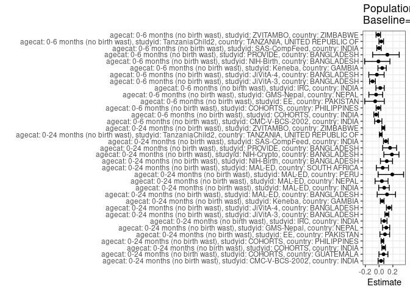

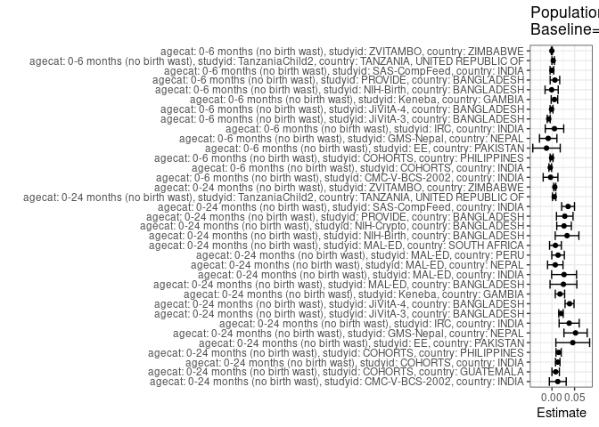

## Results Table

### Parameter: TSM

| agecat | studyid | country | intervention_level | baseline_level | estimate | ci_lower | ci_upper |
| --- | --- | --- | --- | --- | --- | --- | --- |
| 0-24 months (no birth wast) | CMC-V-BCS-2002 | INDIA | Normal or high birthweight | NA | 0.4386917 | 0.3842105 | 0.4931729 |
| 0-24 months (no birth wast) | CMC-V-BCS-2002 | INDIA | Low birthweight | NA | 0.5586014 | 0.3994221 | 0.7177807 |
| 0-24 months (no birth wast) | COHORTS | GUATEMALA | Normal or high birthweight | NA | 0.1172170 | 0.0954136 | 0.1390205 |
| 0-24 months (no birth wast) | COHORTS | GUATEMALA | Low birthweight | NA | 0.2139899 | 0.1202992 | 0.3076807 |
| 0-24 months (no birth wast) | COHORTS | INDIA | Normal or high birthweight | NA | 0.1792812 | 0.1689578 | 0.1896047 |
| 0-24 months (no birth wast) | COHORTS | INDIA | Low birthweight | NA | 0.2504553 | 0.2254498 | 0.2754609 |
| 0-24 months (no birth wast) | COHORTS | PHILIPPINES | Normal or high birthweight | NA | 0.2891583 | 0.2720650 | 0.3062515 |
| 0-24 months (no birth wast) | COHORTS | PHILIPPINES | Low birthweight | NA | 0.4510697 | 0.3923664 | 0.5097729 |
| 0-24 months (no birth wast) | EE | PAKISTAN | Normal or high birthweight | NA | 0.4912117 | 0.4281838 | 0.5542396 |
| 0-24 months (no birth wast) | EE | PAKISTAN | Low birthweight | NA | 0.6242914 | 0.5412890 | 0.7072938 |
| 0-24 months (no birth wast) | GMS-Nepal | NEPAL | Normal or high birthweight | NA | 0.4485565 | 0.4028869 | 0.4942262 |
| 0-24 months (no birth wast) | GMS-Nepal | NEPAL | Low birthweight | NA | 0.6191474 | 0.5503463 | 0.6879486 |
| 0-24 months (no birth wast) | IRC | INDIA | Normal or high birthweight | NA | 0.4830373 | 0.4293329 | 0.5367416 |
| 0-24 months (no birth wast) | IRC | INDIA | Low birthweight | NA | 0.7205824 | 0.6077932 | 0.8333716 |
| 0-24 months (no birth wast) | JiVitA-3 | BANGLADESH | Normal or high birthweight | NA | 0.1555718 | 0.1477655 | 0.1633781 |
| 0-24 months (no birth wast) | JiVitA-3 | BANGLADESH | Low birthweight | NA | 0.2046755 | 0.1955157 | 0.2138354 |
| 0-24 months (no birth wast) | JiVitA-4 | BANGLADESH | Normal or high birthweight | NA | 0.2285525 | 0.2110232 | 0.2460818 |
| 0-24 months (no birth wast) | JiVitA-4 | BANGLADESH | Low birthweight | NA | 0.3793922 | 0.3461769 | 0.4126075 |
| 0-24 months (no birth wast) | Keneba | GAMBIA | Normal or high birthweight | NA | 0.3697792 | 0.3435995 | 0.3959589 |
| 0-24 months (no birth wast) | Keneba | GAMBIA | Low birthweight | NA | 0.4983915 | 0.4319923 | 0.5647908 |
| 0-24 months (no birth wast) | MAL-ED | BANGLADESH | Normal or high birthweight | NA | 0.1938763 | 0.1402606 | 0.2474920 |
| 0-24 months (no birth wast) | MAL-ED | BANGLADESH | Low birthweight | NA | 0.3070754 | 0.1851976 | 0.4289531 |
| 0-24 months (no birth wast) | MAL-ED | INDIA | Normal or high birthweight | NA | 0.3333652 | 0.2682601 | 0.3984703 |
| 0-24 months (no birth wast) | MAL-ED | INDIA | Low birthweight | NA | 0.5557754 | 0.3817811 | 0.7297697 |
| 0-24 months (no birth wast) | MAL-ED | NEPAL | Normal or high birthweight | NA | 0.1737089 | 0.1227202 | 0.2246976 |
| 0-24 months (no birth wast) | MAL-ED | NEPAL | Low birthweight | NA | 0.2631579 | 0.0647291 | 0.4615867 |
| 0-24 months (no birth wast) | MAL-ED | PERU | Normal or high birthweight | NA | 0.0567376 | 0.0296916 | 0.0837836 |
| 0-24 months (no birth wast) | MAL-ED | PERU | Low birthweight | NA | 0.2941176 | 0.0771586 | 0.5110767 |
| 0-24 months (no birth wast) | MAL-ED | SOUTH AFRICA | Normal or high birthweight | NA | 0.1393728 | 0.0992386 | 0.1795070 |
| 0-24 months (no birth wast) | MAL-ED | SOUTH AFRICA | Low birthweight | NA | 0.2631579 | 0.0648329 | 0.4614829 |
| 0-24 months (no birth wast) | NIH-Birth | BANGLADESH | Normal or high birthweight | NA | 0.2643951 | 0.2210627 | 0.3077274 |
| 0-24 months (no birth wast) | NIH-Birth | BANGLADESH | Low birthweight | NA | 0.3712390 | 0.3006233 | 0.4418547 |
| 0-24 months (no birth wast) | NIH-Crypto | BANGLADESH | Normal or high birthweight | NA | 0.1164947 | 0.0903646 | 0.1426247 |
| 0-24 months (no birth wast) | NIH-Crypto | BANGLADESH | Low birthweight | NA | 0.2300204 | 0.1669847 | 0.2930562 |
| 0-24 months (no birth wast) | PROVIDE | BANGLADESH | Normal or high birthweight | NA | 0.1492852 | 0.1187769 | 0.1797935 |
| 0-24 months (no birth wast) | PROVIDE | BANGLADESH | Low birthweight | NA | 0.2751123 | 0.2039584 | 0.3462663 |
| 0-24 months (no birth wast) | SAS-CompFeed | INDIA | Normal or high birthweight | NA | 0.3269301 | 0.2818254 | 0.3720349 |
| 0-24 months (no birth wast) | SAS-CompFeed | INDIA | Low birthweight | NA | 0.4738482 | 0.3991514 | 0.5485451 |
| 0-24 months (no birth wast) | TanzaniaChild2 | TANZANIA, UNITED REPUBLIC OF | Normal or high birthweight | NA | 0.1930723 | 0.1768618 | 0.2092827 |
| 0-24 months (no birth wast) | TanzaniaChild2 | TANZANIA, UNITED REPUBLIC OF | Low birthweight | NA | 0.3573186 | 0.2514112 | 0.4632260 |
| 0-24 months (no birth wast) | ZVITAMBO | ZIMBABWE | Normal or high birthweight | NA | 0.0957218 | 0.0904374 | 0.1010063 |
| 0-24 months (no birth wast) | ZVITAMBO | ZIMBABWE | Low birthweight | NA | 0.1454287 | 0.1285759 | 0.1622815 |
| 0-6 months (no birth wast) | CMC-V-BCS-2002 | INDIA | Normal or high birthweight | NA | 0.3112863 | 0.2595924 | 0.3629802 |
| 0-6 months (no birth wast) | CMC-V-BCS-2002 | INDIA | Low birthweight | NA | 0.3351724 | 0.1840768 | 0.4862680 |
| 0-6 months (no birth wast) | COHORTS | INDIA | Normal or high birthweight | NA | 0.0919821 | 0.0839856 | 0.0999785 |
| 0-6 months (no birth wast) | COHORTS | INDIA | Low birthweight | NA | 0.0701318 | 0.0538039 | 0.0864598 |
| 0-6 months (no birth wast) | COHORTS | PHILIPPINES | Normal or high birthweight | NA | 0.0962768 | 0.0851173 | 0.1074363 |
| 0-6 months (no birth wast) | COHORTS | PHILIPPINES | Low birthweight | NA | 0.0821312 | 0.0492963 | 0.1149660 |
| 0-6 months (no birth wast) | EE | PAKISTAN | Normal or high birthweight | NA | 0.2260073 | 0.1730601 | 0.2789545 |
| 0-6 months (no birth wast) | EE | PAKISTAN | Low birthweight | NA | 0.1855246 | 0.1182163 | 0.2528328 |
| 0-6 months (no birth wast) | GMS-Nepal | NEPAL | Normal or high birthweight | NA | 0.2002279 | 0.1631082 | 0.2373477 |
| 0-6 months (no birth wast) | GMS-Nepal | NEPAL | Low birthweight | NA | 0.1718345 | 0.1173994 | 0.2262697 |
| 0-6 months (no birth wast) | IRC | INDIA | Normal or high birthweight | NA | 0.3329698 | 0.2815028 | 0.3844367 |
| 0-6 months (no birth wast) | IRC | INDIA | Low birthweight | NA | 0.3605081 | 0.2375048 | 0.4835114 |
| 0-6 months (no birth wast) | JiVitA-3 | BANGLADESH | Normal or high birthweight | NA | 0.0825895 | 0.0767938 | 0.0883851 |
| 0-6 months (no birth wast) | JiVitA-3 | BANGLADESH | Low birthweight | NA | 0.0654336 | 0.0598738 | 0.0709934 |
| 0-6 months (no birth wast) | JiVitA-4 | BANGLADESH | Normal or high birthweight | NA | 0.0297451 | 0.0235896 | 0.0359006 |
| 0-6 months (no birth wast) | JiVitA-4 | BANGLADESH | Low birthweight | NA | 0.0246750 | 0.0139981 | 0.0353520 |
| 0-6 months (no birth wast) | Keneba | GAMBIA | Normal or high birthweight | NA | 0.1136938 | 0.0963941 | 0.1309934 |
| 0-6 months (no birth wast) | Keneba | GAMBIA | Low birthweight | NA | 0.1637375 | 0.1137118 | 0.2137632 |
| 0-6 months (no birth wast) | NIH-Birth | BANGLADESH | Normal or high birthweight | NA | 0.0805375 | 0.0537212 | 0.1073537 |
| 0-6 months (no birth wast) | NIH-Birth | BANGLADESH | Low birthweight | NA | 0.0823918 | 0.0414027 | 0.1233808 |
| 0-6 months (no birth wast) | PROVIDE | BANGLADESH | Normal or high birthweight | NA | 0.0476197 | 0.0293533 | 0.0658861 |
| 0-6 months (no birth wast) | PROVIDE | BANGLADESH | Low birthweight | NA | 0.0782800 | 0.0329167 | 0.1236433 |
| 0-6 months (no birth wast) | SAS-CompFeed | INDIA | Normal or high birthweight | NA | 0.1263902 | 0.0938616 | 0.1589189 |
| 0-6 months (no birth wast) | SAS-CompFeed | INDIA | Low birthweight | NA | 0.1267143 | 0.0994030 | 0.1540256 |
| 0-6 months (no birth wast) | TanzaniaChild2 | TANZANIA, UNITED REPUBLIC OF | Normal or high birthweight | NA | 0.0823288 | 0.0710244 | 0.0936332 |
| 0-6 months (no birth wast) | TanzaniaChild2 | TANZANIA, UNITED REPUBLIC OF | Low birthweight | NA | 0.1609992 | 0.0766400 | 0.2453583 |
| 0-6 months (no birth wast) | ZVITAMBO | ZIMBABWE | Normal or high birthweight | NA | 0.0324462 | 0.0292463 | 0.0356460 |
| 0-6 months (no birth wast) | ZVITAMBO | ZIMBABWE | Low birthweight | NA | 0.0297150 | 0.0213140 | 0.0381160 |

### Parameter: E(Y)

| agecat | studyid | country | intervention_level | baseline_level | estimate | ci_lower | ci_upper |
| --- | --- | --- | --- | --- | --- | --- | --- |
| 0-24 months (no birth wast) | CMC-V-BCS-2002 | INDIA | NA | NA | 0.4515235 | 0.4001173 | 0.5029298 |
| 0-24 months (no birth wast) | COHORTS | GUATEMALA | NA | NA | 0.1254089 | 0.1039619 | 0.1468560 |
| 0-24 months (no birth wast) | COHORTS | INDIA | NA | NA | 0.1920601 | 0.1825006 | 0.2016195 |
| 0-24 months (no birth wast) | COHORTS | PHILIPPINES | NA | NA | 0.3038655 | 0.2873358 | 0.3203952 |
| 0-24 months (no birth wast) | EE | PAKISTAN | NA | NA | 0.5372340 | 0.4867685 | 0.5876996 |
| 0-24 months (no birth wast) | GMS-Nepal | NEPAL | NA | NA | 0.5007587 | 0.4625551 | 0.5389624 |
| 0-24 months (no birth wast) | IRC | INDIA | NA | NA | 0.5210918 | 0.4722583 | 0.5699254 |
| 0-24 months (no birth wast) | JiVitA-3 | BANGLADESH | NA | NA | 0.1755073 | 0.1694892 | 0.1815253 |
| 0-24 months (no birth wast) | JiVitA-4 | BANGLADESH | NA | NA | 0.2674393 | 0.2524050 | 0.2824735 |
| 0-24 months (no birth wast) | Keneba | GAMBIA | NA | NA | 0.3874755 | 0.3630804 | 0.4118706 |
| 0-24 months (no birth wast) | MAL-ED | BANGLADESH | NA | NA | 0.2192308 | 0.1688447 | 0.2696168 |
| 0-24 months (no birth wast) | MAL-ED | INDIA | NA | NA | 0.3601695 | 0.2987933 | 0.4215457 |
| 0-24 months (no birth wast) | MAL-ED | NEPAL | NA | NA | 0.1810345 | 0.1313803 | 0.2306886 |
| 0-24 months (no birth wast) | MAL-ED | PERU | NA | NA | 0.0702341 | 0.0412206 | 0.0992477 |
| 0-24 months (no birth wast) | MAL-ED | SOUTH AFRICA | NA | NA | 0.1470588 | 0.1073119 | 0.1868057 |
| 0-24 months (no birth wast) | NIH-Birth | BANGLADESH | NA | NA | 0.2977625 | 0.2605481 | 0.3349769 |
| 0-24 months (no birth wast) | NIH-Crypto | BANGLADESH | NA | NA | 0.1432361 | 0.1182149 | 0.1682572 |
| 0-24 months (no birth wast) | PROVIDE | BANGLADESH | NA | NA | 0.1775837 | 0.1489858 | 0.2061816 |
| 0-24 months (no birth wast) | SAS-CompFeed | INDIA | NA | NA | 0.3626005 | 0.3118807 | 0.4133204 |
| 0-24 months (no birth wast) | TanzaniaChild2 | TANZANIA, UNITED REPUBLIC OF | NA | NA | 0.1979652 | 0.1818822 | 0.2140482 |
| 0-24 months (no birth wast) | ZVITAMBO | ZIMBABWE | NA | NA | 0.1019642 | 0.0968771 | 0.1070514 |
| 0-6 months (no birth wast) | CMC-V-BCS-2002 | INDIA | NA | NA | 0.3081395 | 0.2592761 | 0.3570030 |
| 0-6 months (no birth wast) | COHORTS | INDIA | NA | NA | 0.0882207 | 0.0810753 | 0.0953662 |
| 0-6 months (no birth wast) | COHORTS | PHILIPPINES | NA | NA | 0.0954638 | 0.0848652 | 0.1060624 |
| 0-6 months (no birth wast) | EE | PAKISTAN | NA | NA | 0.2139037 | 0.1722896 | 0.2555179 |
| 0-6 months (no birth wast) | GMS-Nepal | NEPAL | NA | NA | 0.1918877 | 0.1613794 | 0.2223959 |
| 0-6 months (no birth wast) | IRC | INDIA | NA | NA | 0.3385417 | 0.2911496 | 0.3859338 |
| 0-6 months (no birth wast) | JiVitA-3 | BANGLADESH | NA | NA | 0.0754015 | 0.0712481 | 0.0795550 |
| 0-6 months (no birth wast) | JiVitA-4 | BANGLADESH | NA | NA | 0.0288198 | 0.0235259 | 0.0341136 |
| 0-6 months (no birth wast) | Keneba | GAMBIA | NA | NA | 0.1191573 | 0.1028598 | 0.1354549 |
| 0-6 months (no birth wast) | NIH-Birth | BANGLADESH | NA | NA | 0.0797872 | 0.0574049 | 0.1021695 |
| 0-6 months (no birth wast) | PROVIDE | BANGLADESH | NA | NA | 0.0541728 | 0.0371844 | 0.0711612 |
| 0-6 months (no birth wast) | SAS-CompFeed | INDIA | NA | NA | 0.1262799 | 0.0958566 | 0.1567031 |
| 0-6 months (no birth wast) | TanzaniaChild2 | TANZANIA, UNITED REPUBLIC OF | NA | NA | 0.0850702 | 0.0737905 | 0.0963499 |
| 0-6 months (no birth wast) | ZVITAMBO | ZIMBABWE | NA | NA | 0.0320984 | 0.0291065 | 0.0350903 |

### Parameter: RR

| agecat | studyid | country | intervention_level | baseline_level | estimate | ci_lower | ci_upper |
| --- | --- | --- | --- | --- | --- | --- | --- |
| 0-24 months (no birth wast) | CMC-V-BCS-2002 | INDIA | Normal or high birthweight | Normal or high birthweight | 1.0000000 | 1.0000000 | 1.0000000 |
| 0-24 months (no birth wast) | CMC-V-BCS-2002 | INDIA | Low birthweight | Normal or high birthweight | 1.2733349 | 0.9331323 | 1.7375690 |
| 0-24 months (no birth wast) | COHORTS | GUATEMALA | Normal or high birthweight | Normal or high birthweight | 1.0000000 | 1.0000000 | 1.0000000 |
| 0-24 months (no birth wast) | COHORTS | GUATEMALA | Low birthweight | Normal or high birthweight | 1.8255877 | 1.1344126 | 2.9378821 |
| 0-24 months (no birth wast) | COHORTS | INDIA | Normal or high birthweight | Normal or high birthweight | 1.0000000 | 1.0000000 | 1.0000000 |
| 0-24 months (no birth wast) | COHORTS | INDIA | Low birthweight | Normal or high birthweight | 1.3969970 | 1.2452433 | 1.5672445 |
| 0-24 months (no birth wast) | COHORTS | PHILIPPINES | Normal or high birthweight | Normal or high birthweight | 1.0000000 | 1.0000000 | 1.0000000 |
| 0-24 months (no birth wast) | COHORTS | PHILIPPINES | Low birthweight | Normal or high birthweight | 1.5599403 | 1.3527552 | 1.7988575 |
| 0-24 months (no birth wast) | EE | PAKISTAN | Normal or high birthweight | Normal or high birthweight | 1.0000000 | 1.0000000 | 1.0000000 |
| 0-24 months (no birth wast) | EE | PAKISTAN | Low birthweight | Normal or high birthweight | 1.2709212 | 1.0562684 | 1.5291955 |
| 0-24 months (no birth wast) | GMS-Nepal | NEPAL | Normal or high birthweight | Normal or high birthweight | 1.0000000 | 1.0000000 | 1.0000000 |
| 0-24 months (no birth wast) | GMS-Nepal | NEPAL | Low birthweight | Normal or high birthweight | 1.3803108 | 1.1874130 | 1.6045454 |
| 0-24 months (no birth wast) | IRC | INDIA | Normal or high birthweight | Normal or high birthweight | 1.0000000 | 1.0000000 | 1.0000000 |
| 0-24 months (no birth wast) | IRC | INDIA | Low birthweight | Normal or high birthweight | 1.4917740 | 1.2303598 | 1.8087309 |
| 0-24 months (no birth wast) | JiVitA-3 | BANGLADESH | Normal or high birthweight | Normal or high birthweight | 1.0000000 | 1.0000000 | 1.0000000 |
| 0-24 months (no birth wast) | JiVitA-3 | BANGLADESH | Low birthweight | Normal or high birthweight | 1.3156338 | 1.2324243 | 1.4044613 |
| 0-24 months (no birth wast) | JiVitA-4 | BANGLADESH | Normal or high birthweight | Normal or high birthweight | 1.0000000 | 1.0000000 | 1.0000000 |
| 0-24 months (no birth wast) | JiVitA-4 | BANGLADESH | Low birthweight | Normal or high birthweight | 1.6599787 | 1.4756186 | 1.8673722 |
| 0-24 months (no birth wast) | Keneba | GAMBIA | Normal or high birthweight | Normal or high birthweight | 1.0000000 | 1.0000000 | 1.0000000 |
| 0-24 months (no birth wast) | Keneba | GAMBIA | Low birthweight | Normal or high birthweight | 1.3478084 | 1.1598051 | 1.5662869 |
| 0-24 months (no birth wast) | MAL-ED | BANGLADESH | Normal or high birthweight | Normal or high birthweight | 1.0000000 | 1.0000000 | 1.0000000 |
| 0-24 months (no birth wast) | MAL-ED | BANGLADESH | Low birthweight | Normal or high birthweight | 1.5838726 | 0.9753210 | 2.5721299 |
| 0-24 months (no birth wast) | MAL-ED | INDIA | Normal or high birthweight | Normal or high birthweight | 1.0000000 | 1.0000000 | 1.0000000 |
| 0-24 months (no birth wast) | MAL-ED | INDIA | Low birthweight | Normal or high birthweight | 1.6671670 | 1.1515050 | 2.4137506 |
| 0-24 months (no birth wast) | MAL-ED | NEPAL | Normal or high birthweight | Normal or high birthweight | 1.0000000 | 1.0000000 | 1.0000000 |
| 0-24 months (no birth wast) | MAL-ED | NEPAL | Low birthweight | Normal or high birthweight | 1.5149360 | 0.6745061 | 3.4025355 |
| 0-24 months (no birth wast) | MAL-ED | PERU | Normal or high birthweight | Normal or high birthweight | 1.0000000 | 1.0000000 | 1.0000000 |
| 0-24 months (no birth wast) | MAL-ED | PERU | Low birthweight | Normal or high birthweight | 5.1838235 | 2.1538670 | 12.4761774 |
| 0-24 months (no birth wast) | MAL-ED | SOUTH AFRICA | Normal or high birthweight | Normal or high birthweight | 1.0000000 | 1.0000000 | 1.0000000 |
| 0-24 months (no birth wast) | MAL-ED | SOUTH AFRICA | Low birthweight | Normal or high birthweight | 1.8881579 | 0.8426742 | 4.2307456 |
| 0-24 months (no birth wast) | NIH-Birth | BANGLADESH | Normal or high birthweight | Normal or high birthweight | 1.0000000 | 1.0000000 | 1.0000000 |
| 0-24 months (no birth wast) | NIH-Birth | BANGLADESH | Low birthweight | Normal or high birthweight | 1.4041070 | 1.0923751 | 1.8047980 |
| 0-24 months (no birth wast) | NIH-Crypto | BANGLADESH | Normal or high birthweight | Normal or high birthweight | 1.0000000 | 1.0000000 | 1.0000000 |
| 0-24 months (no birth wast) | NIH-Crypto | BANGLADESH | Low birthweight | Normal or high birthweight | 1.9745147 | 1.3855295 | 2.8138762 |
| 0-24 months (no birth wast) | PROVIDE | BANGLADESH | Normal or high birthweight | Normal or high birthweight | 1.0000000 | 1.0000000 | 1.0000000 |
| 0-24 months (no birth wast) | PROVIDE | BANGLADESH | Low birthweight | Normal or high birthweight | 1.8428640 | 1.3258535 | 2.5614804 |
| 0-24 months (no birth wast) | SAS-CompFeed | INDIA | Normal or high birthweight | Normal or high birthweight | 1.0000000 | 1.0000000 | 1.0000000 |
| 0-24 months (no birth wast) | SAS-CompFeed | INDIA | Low birthweight | Normal or high birthweight | 1.4493868 | 1.3032536 | 1.6119060 |
| 0-24 months (no birth wast) | TanzaniaChild2 | TANZANIA, UNITED REPUBLIC OF | Normal or high birthweight | Normal or high birthweight | 1.0000000 | 1.0000000 | 1.0000000 |
| 0-24 months (no birth wast) | TanzaniaChild2 | TANZANIA, UNITED REPUBLIC OF | Low birthweight | Normal or high birthweight | 1.8506987 | 1.3598532 | 2.5187171 |
| 0-24 months (no birth wast) | ZVITAMBO | ZIMBABWE | Normal or high birthweight | Normal or high birthweight | 1.0000000 | 1.0000000 | 1.0000000 |
| 0-24 months (no birth wast) | ZVITAMBO | ZIMBABWE | Low birthweight | Normal or high birthweight | 1.5192848 | 1.3363412 | 1.7272732 |
| 0-6 months (no birth wast) | CMC-V-BCS-2002 | INDIA | Normal or high birthweight | Normal or high birthweight | 1.0000000 | 1.0000000 | 1.0000000 |
| 0-6 months (no birth wast) | CMC-V-BCS-2002 | INDIA | Low birthweight | Normal or high birthweight | 1.0767336 | 0.6655567 | 1.7419330 |
| 0-6 months (no birth wast) | COHORTS | INDIA | Normal or high birthweight | Normal or high birthweight | 1.0000000 | 1.0000000 | 1.0000000 |
| 0-6 months (no birth wast) | COHORTS | INDIA | Low birthweight | Normal or high birthweight | 0.7624513 | 0.5946623 | 0.9775834 |
| 0-6 months (no birth wast) | COHORTS | PHILIPPINES | Normal or high birthweight | Normal or high birthweight | 1.0000000 | 1.0000000 | 1.0000000 |
| 0-6 months (no birth wast) | COHORTS | PHILIPPINES | Low birthweight | Normal or high birthweight | 0.8530735 | 0.5625988 | 1.2935229 |
| 0-6 months (no birth wast) | EE | PAKISTAN | Normal or high birthweight | Normal or high birthweight | 1.0000000 | 1.0000000 | 1.0000000 |
| 0-6 months (no birth wast) | EE | PAKISTAN | Low birthweight | Normal or high birthweight | 0.8208785 | 0.5321331 | 1.2663027 |
| 0-6 months (no birth wast) | GMS-Nepal | NEPAL | Normal or high birthweight | Normal or high birthweight | 1.0000000 | 1.0000000 | 1.0000000 |
| 0-6 months (no birth wast) | GMS-Nepal | NEPAL | Low birthweight | Normal or high birthweight | 0.8581946 | 0.5945824 | 1.2386812 |
| 0-6 months (no birth wast) | IRC | INDIA | Normal or high birthweight | Normal or high birthweight | 1.0000000 | 1.0000000 | 1.0000000 |
| 0-6 months (no birth wast) | IRC | INDIA | Low birthweight | Normal or high birthweight | 1.0827053 | 0.7450851 | 1.5733112 |
| 0-6 months (no birth wast) | JiVitA-3 | BANGLADESH | Normal or high birthweight | Normal or high birthweight | 1.0000000 | 1.0000000 | 1.0000000 |
| 0-6 months (no birth wast) | JiVitA-3 | BANGLADESH | Low birthweight | Normal or high birthweight | 0.7922753 | 0.7124881 | 0.8809973 |
| 0-6 months (no birth wast) | JiVitA-4 | BANGLADESH | Normal or high birthweight | Normal or high birthweight | 1.0000000 | 1.0000000 | 1.0000000 |
| 0-6 months (no birth wast) | JiVitA-4 | BANGLADESH | Low birthweight | Normal or high birthweight | 0.8295488 | 0.5092297 | 1.3513573 |
| 0-6 months (no birth wast) | Keneba | GAMBIA | Normal or high birthweight | Normal or high birthweight | 1.0000000 | 1.0000000 | 1.0000000 |
| 0-6 months (no birth wast) | Keneba | GAMBIA | Low birthweight | Normal or high birthweight | 1.4401625 | 1.0237927 | 2.0258672 |
| 0-6 months (no birth wast) | NIH-Birth | BANGLADESH | Normal or high birthweight | Normal or high birthweight | 1.0000000 | 1.0000000 | 1.0000000 |
| 0-6 months (no birth wast) | NIH-Birth | BANGLADESH | Low birthweight | Normal or high birthweight | 1.0230241 | 0.5625089 | 1.8605543 |
| 0-6 months (no birth wast) | PROVIDE | BANGLADESH | Normal or high birthweight | Normal or high birthweight | 1.0000000 | 1.0000000 | 1.0000000 |
| 0-6 months (no birth wast) | PROVIDE | BANGLADESH | Low birthweight | Normal or high birthweight | 1.6438574 | 0.8201282 | 3.2949328 |
| 0-6 months (no birth wast) | SAS-CompFeed | INDIA | Normal or high birthweight | Normal or high birthweight | 1.0000000 | 1.0000000 | 1.0000000 |
| 0-6 months (no birth wast) | SAS-CompFeed | INDIA | Low birthweight | Normal or high birthweight | 1.0025642 | 0.8581704 | 1.1712533 |
| 0-6 months (no birth wast) | TanzaniaChild2 | TANZANIA, UNITED REPUBLIC OF | Normal or high birthweight | Normal or high birthweight | 1.0000000 | 1.0000000 | 1.0000000 |
| 0-6 months (no birth wast) | TanzaniaChild2 | TANZANIA, UNITED REPUBLIC OF | Low birthweight | Normal or high birthweight | 1.9555639 | 1.1375181 | 3.3619069 |
| 0-6 months (no birth wast) | ZVITAMBO | ZIMBABWE | Normal or high birthweight | Normal or high birthweight | 1.0000000 | 1.0000000 | 1.0000000 |
| 0-6 months (no birth wast) | ZVITAMBO | ZIMBABWE | Low birthweight | Normal or high birthweight | 0.9158238 | 0.6788697 | 1.2354851 |

### Parameter: PAR

| agecat | studyid | country | intervention_level | baseline_level | estimate | ci_lower | ci_upper |
| --- | --- | --- | --- | --- | --- | --- | --- |
| 0-24 months (no birth wast) | CMC-V-BCS-2002 | INDIA | Normal or high birthweight | NA | 0.0128318 | -0.0058587 | 0.0315224 |
| 0-24 months (no birth wast) | COHORTS | GUATEMALA | Normal or high birthweight | NA | 0.0081919 | -0.0000492 | 0.0164330 |
| 0-24 months (no birth wast) | COHORTS | INDIA | Normal or high birthweight | NA | 0.0127789 | 0.0078298 | 0.0177280 |
| 0-24 months (no birth wast) | COHORTS | PHILIPPINES | Normal or high birthweight | NA | 0.0147073 | 0.0089168 | 0.0204977 |
| 0-24 months (no birth wast) | EE | PAKISTAN | Normal or high birthweight | NA | 0.0460223 | 0.0086530 | 0.0833917 |
| 0-24 months (no birth wast) | GMS-Nepal | NEPAL | Normal or high birthweight | NA | 0.0522022 | 0.0265301 | 0.0778743 |
| 0-24 months (no birth wast) | IRC | INDIA | Normal or high birthweight | NA | 0.0380546 | 0.0157944 | 0.0603147 |
| 0-24 months (no birth wast) | JiVitA-3 | BANGLADESH | Normal or high birthweight | NA | 0.0199354 | 0.0150303 | 0.0248406 |
| 0-24 months (no birth wast) | JiVitA-4 | BANGLADESH | Normal or high birthweight | NA | 0.0388868 | 0.0289773 | 0.0487963 |
| 0-24 months (no birth wast) | Keneba | GAMBIA | Normal or high birthweight | NA | 0.0176963 | 0.0073252 | 0.0280674 |
| 0-24 months (no birth wast) | MAL-ED | BANGLADESH | Normal or high birthweight | NA | 0.0253545 | -0.0042377 | 0.0549466 |
| 0-24 months (no birth wast) | MAL-ED | INDIA | Normal or high birthweight | NA | 0.0268043 | -0.0007558 | 0.0543645 |
| 0-24 months (no birth wast) | MAL-ED | NEPAL | Normal or high birthweight | NA | 0.0073256 | -0.0097485 | 0.0243997 |
| 0-24 months (no birth wast) | MAL-ED | PERU | Normal or high birthweight | NA | 0.0134965 | -0.0004132 | 0.0274062 |
| 0-24 months (no birth wast) | MAL-ED | SOUTH AFRICA | Normal or high birthweight | NA | 0.0076860 | -0.0053175 | 0.0206895 |
| 0-24 months (no birth wast) | NIH-Birth | BANGLADESH | Normal or high birthweight | NA | 0.0333674 | 0.0071606 | 0.0595742 |
| 0-24 months (no birth wast) | NIH-Crypto | BANGLADESH | Normal or high birthweight | NA | 0.0267414 | 0.0105616 | 0.0429212 |
| 0-24 months (no birth wast) | PROVIDE | BANGLADESH | Normal or high birthweight | NA | 0.0282985 | 0.0099810 | 0.0466160 |
| 0-24 months (no birth wast) | SAS-CompFeed | INDIA | Normal or high birthweight | NA | 0.0356704 | 0.0214579 | 0.0498828 |
| 0-24 months (no birth wast) | TanzaniaChild2 | TANZANIA, UNITED REPUBLIC OF | Normal or high birthweight | NA | 0.0048930 | 0.0011496 | 0.0086363 |
| 0-24 months (no birth wast) | ZVITAMBO | ZIMBABWE | Normal or high birthweight | NA | 0.0062424 | 0.0040363 | 0.0084486 |
| 0-6 months (no birth wast) | CMC-V-BCS-2002 | INDIA | Normal or high birthweight | NA | -0.0031467 | -0.0194482 | 0.0131547 |
| 0-6 months (no birth wast) | COHORTS | INDIA | Normal or high birthweight | NA | -0.0037614 | -0.0067135 | -0.0008092 |
| 0-6 months (no birth wast) | COHORTS | PHILIPPINES | Normal or high birthweight | NA | -0.0008130 | -0.0040431 | 0.0024171 |
| 0-6 months (no birth wast) | EE | PAKISTAN | Normal or high birthweight | NA | -0.0121036 | -0.0424600 | 0.0182529 |
| 0-6 months (no birth wast) | GMS-Nepal | NEPAL | Normal or high birthweight | NA | -0.0083403 | -0.0275954 | 0.0109149 |
| 0-6 months (no birth wast) | IRC | INDIA | Normal or high birthweight | NA | 0.0055719 | -0.0148782 | 0.0260220 |
| 0-6 months (no birth wast) | JiVitA-3 | BANGLADESH | Normal or high birthweight | NA | -0.0071880 | -0.0104139 | -0.0039620 |
| 0-6 months (no birth wast) | JiVitA-4 | BANGLADESH | Normal or high birthweight | NA | -0.0009253 | -0.0041225 | 0.0022718 |
| 0-6 months (no birth wast) | Keneba | GAMBIA | Normal or high birthweight | NA | 0.0054636 | -0.0017845 | 0.0127116 |
| 0-6 months (no birth wast) | NIH-Birth | BANGLADESH | Normal or high birthweight | NA | -0.0007502 | -0.0153015 | 0.0138011 |
| 0-6 months (no birth wast) | PROVIDE | BANGLADESH | Normal or high birthweight | NA | 0.0065531 | -0.0039971 | 0.0171033 |
| 0-6 months (no birth wast) | SAS-CompFeed | INDIA | Normal or high birthweight | NA | -0.0001104 | -0.0041704 | 0.0039496 |
| 0-6 months (no birth wast) | TanzaniaChild2 | TANZANIA, UNITED REPUBLIC OF | Normal or high birthweight | NA | 0.0027414 | -0.0001051 | 0.0055879 |
| 0-6 months (no birth wast) | ZVITAMBO | ZIMBABWE | Normal or high birthweight | NA | -0.0003478 | -0.0013983 | 0.0007027 |

### Parameter: PAF

| agecat | studyid | country | intervention_level | baseline_level | estimate | ci_lower | ci_upper |
| --- | --- | --- | --- | --- | --- | --- | --- |
| 0-24 months (no birth wast) | CMC-V-BCS-2002 | INDIA | Normal or high birthweight | NA | 0.0284190 | -0.0139601 | 0.0690268 |
| 0-24 months (no birth wast) | COHORTS | GUATEMALA | Normal or high birthweight | NA | 0.0653217 | -0.0019923 | 0.1281135 |
| 0-24 months (no birth wast) | COHORTS | INDIA | Normal or high birthweight | NA | 0.0665358 | 0.0405245 | 0.0918419 |
| 0-24 months (no birth wast) | COHORTS | PHILIPPINES | Normal or high birthweight | NA | 0.0484005 | 0.0291716 | 0.0672486 |
| 0-24 months (no birth wast) | EE | PAKISTAN | Normal or high birthweight | NA | 0.0856653 | 0.0128245 | 0.1531314 |
| 0-24 months (no birth wast) | GMS-Nepal | NEPAL | Normal or high birthweight | NA | 0.1042462 | 0.0509744 | 0.1545276 |
| 0-24 months (no birth wast) | IRC | INDIA | Normal or high birthweight | NA | 0.0730285 | 0.0287272 | 0.1153092 |
| 0-24 months (no birth wast) | JiVitA-3 | BANGLADESH | Normal or high birthweight | NA | 0.1135875 | 0.0848704 | 0.1414035 |
| 0-24 months (no birth wast) | JiVitA-4 | BANGLADESH | Normal or high birthweight | NA | 0.1454042 | 0.1070827 | 0.1820811 |
| 0-24 months (no birth wast) | Keneba | GAMBIA | Normal or high birthweight | NA | 0.0456708 | 0.0184684 | 0.0721193 |
| 0-24 months (no birth wast) | MAL-ED | BANGLADESH | Normal or high birthweight | NA | 0.1156519 | -0.0276019 | 0.2389353 |
| 0-24 months (no birth wast) | MAL-ED | INDIA | Normal or high birthweight | NA | 0.0744214 | -0.0053196 | 0.1478375 |
| 0-24 months (no birth wast) | MAL-ED | NEPAL | Normal or high birthweight | NA | 0.0404650 | -0.0582243 | 0.1299506 |
| 0-24 months (no birth wast) | MAL-ED | PERU | Normal or high birthweight | NA | 0.1921648 | -0.0139099 | 0.3563554 |
| 0-24 months (no birth wast) | MAL-ED | SOUTH AFRICA | Normal or high birthweight | NA | 0.0522648 | -0.0395781 | 0.1359937 |
| 0-24 months (no birth wast) | NIH-Birth | BANGLADESH | Normal or high birthweight | NA | 0.1120605 | 0.0198468 | 0.1955987 |
| 0-24 months (no birth wast) | NIH-Crypto | BANGLADESH | Normal or high birthweight | NA | 0.1866946 | 0.0696532 | 0.2890118 |
| 0-24 months (no birth wast) | PROVIDE | BANGLADESH | Normal or high birthweight | NA | 0.1593530 | 0.0521899 | 0.2543998 |
| 0-24 months (no birth wast) | SAS-CompFeed | INDIA | Normal or high birthweight | NA | 0.0983738 | 0.0634819 | 0.1319658 |
| 0-24 months (no birth wast) | TanzaniaChild2 | TANZANIA, UNITED REPUBLIC OF | Normal or high birthweight | NA | 0.0247163 | 0.0056824 | 0.0433859 |
| 0-24 months (no birth wast) | ZVITAMBO | ZIMBABWE | Normal or high birthweight | NA | 0.0612218 | 0.0395067 | 0.0824460 |
| 0-6 months (no birth wast) | CMC-V-BCS-2002 | INDIA | Normal or high birthweight | NA | -0.0102121 | -0.0645306 | 0.0413348 |
| 0-6 months (no birth wast) | COHORTS | INDIA | Normal or high birthweight | NA | -0.0426357 | -0.0764724 | -0.0098626 |
| 0-6 months (no birth wast) | COHORTS | PHILIPPINES | Normal or high birthweight | NA | -0.0085163 | -0.0429147 | 0.0247476 |
| 0-6 months (no birth wast) | EE | PAKISTAN | Normal or high birthweight | NA | -0.0565842 | -0.2082127 | 0.0760152 |
| 0-6 months (no birth wast) | GMS-Nepal | NEPAL | Normal or high birthweight | NA | -0.0434643 | -0.1485609 | 0.0520157 |
| 0-6 months (no birth wast) | IRC | INDIA | Normal or high birthweight | NA | 0.0164586 | -0.0458688 | 0.0750716 |
| 0-6 months (no birth wast) | JiVitA-3 | BANGLADESH | Normal or high birthweight | NA | -0.0953293 | -0.1380773 | -0.0541870 |
| 0-6 months (no birth wast) | JiVitA-4 | BANGLADESH | Normal or high birthweight | NA | -0.0321077 | -0.1494693 | 0.0732713 |
| 0-6 months (no birth wast) | Keneba | GAMBIA | Normal or high birthweight | NA | 0.0458516 | -0.0167673 | 0.1046140 |
| 0-6 months (no birth wast) | NIH-Birth | BANGLADESH | Normal or high birthweight | NA | -0.0094029 | -0.2092850 | 0.1574409 |
| 0-6 months (no birth wast) | PROVIDE | BANGLADESH | Normal or high birthweight | NA | 0.1209663 | -0.0928764 | 0.2929665 |
| 0-6 months (no birth wast) | SAS-CompFeed | INDIA | Normal or high birthweight | NA | -0.0008741 | -0.0334451 | 0.0306704 |
| 0-6 months (no birth wast) | TanzaniaChild2 | TANZANIA, UNITED REPUBLIC OF | Normal or high birthweight | NA | 0.0322253 | -0.0015826 | 0.0648920 |
| 0-6 months (no birth wast) | ZVITAMBO | ZIMBABWE | Normal or high birthweight | NA | -0.0108346 | -0.0440838 | 0.0213557 |